# Visualize expression data in R

Jakob Willforss

October 21, 2019

# 1 Introduction

This exercise assumes that you are working with two matrices:

- A data matrix containing expression data from multiple samples, with optional annotation columns (can be microarray, RNA-seq, quantitative proteomics)
- A design matrix with the sample column names in one column and sample annotations in the remaining

Example data matrix:

```
pep  RT   s1_1 s1_2 s1_3 s2_1 s2_2 s2_3
ATCA 40.3 20.1 20.2 19.5 22.3 22.5 21.9
GCC  43.0 20.3 19.8 19.5 21.7 21.9 21.2
```

Example design matrix:

```
sample  group  other
s1_1    1      batch1
s1_2    1      batch1
s1_3    1      batch2
s2_1    2      batch2
s2_2    2      batch2
s2_3    2      batch1
```

Note how the entries in the sample column all are present in the data matrix.

You can either use your own data, or download a template dataset:

- Download data matrix
- Download design matrix

## 1.1 Required packages

In order to fully run this exercise, please make sure that you have the tidyverse package installed. This package includes `ggplot2` and `dplyr` which both are used in this exercise.

```r
# Load the tidyverse package
library(tidyverse)
```

## 1.2 Preprocessing the data

If using your own data you need to calculate basic statistics before proceeding with the exercises. For this you could use NormalyzerDE. For small datasets you can run it from: `quantitativeproteomics.org/NormalyzerDE`. If your dataset is larger than 5 MB you could either subset it using the `head` command, run NormalyzerDE locally or ask contact Jakob for help processing it locally.

# 2 Loading data

The file paths here assume that you have a folder `data` within your working directory with a data matrix named `data_matrix.tsv` and a design matrix named `design_matrix.tsv`. Please adjust the path and filename to the data you are using.

```r
data_fp <- "data/data_matrix.tsv"
design_fp <- "data/design_matrix.tsv"

# stringAsFactors - If not used, many columns are read as factors, which can be misinterpreted as integers
data_df <- read.table(data_fp, sep="\t", header = TRUE, stringsAsFactors = FALSE)
design_df <- read.table(design_fp, sep="\t", header = TRUE, stringsAsFactors = FALSE)

# For reference: The above code can be replaced with the following from the readr package
# full_data_df <- read_tsv(data_fp)
# design_df <- read_tsv(design_fp)
```

## 2.1 Investigate the data

- `str`: Produces a brief summary of the object that is given to it
- `head`: Retrieve the first `n` rows from a data.frame or matrix, where `n` here is specified to 10
- `colnames`: Show the column names of the data frame (or matrix)

**Exercise 1:** Inspect your data and make sure you understand what is present in the design- and the data matrix. Verify that the columns are in the format you expect them to be.

```r
str(design_df)
```

```
## 'data.frame':    18 obs. of  4 variables:
##  $ sample  : chr  "dil9_5" "dil9_4" "dil8_1" "dil8_2" ...
##  $ group   : chr  "g9" "g9" "g8" "g8" ...
##  $ time    : chr  "late" "late" "late" "late" ...
##  $ dilution: chr  "high" "high" "high" "high" ...
```

```r
head(design_df, 10)
```

```
##    sample group time dilution
## 1  dil9_5    g9 late     high
## 2  dil9_4    g9 late     high
## 3  dil8_1    g8 late     high
## 4  dil8_2    g8 late     high
## 5  dil8_3    g8 late     high
## 6  dil9_3    g9 late     high
## 7  dil8_5    g8 late      low
## 8  dil8_4    g8 late      low
## 9  dil9_2    g9 late      low
## 10 dil9_1    g9 late      low
```

```r
colnames(design_df)
```

```
## [1] "sample"   "group"    "time"     "dilution"
```

```r
dim(design_df)
```

```
## [1] 18  4
```

```r
str(data_df)
```

```
## 'data.frame':    4008 obs. of  28 variables:
##  $ Average.RT      : num  61.3 99 99 42.7 52.4 ...
##  $ Cluster.ID      : chr  "1418128207109" "1418128190676" "1418128188736" "1418128214098" ...
##  $ Peptide.Sequence: chr  "AAAAAAGDVFKDVQEAK" "AAADYLEVPLYTYLGGFNTK" "AAADYLEVPLYTYLGGFNTK" "AAAEALAQEQAAK" ...
##  $ External.IDs    : chr  "Q99Z57" "P69949" "P69949" "Q9A1Z8" ...
##  $ Charge          : int  3 2 3 2 2 2 3 2 2 2 ...
##  $ Average.m.z     : num  555 1104 736 636 603 ...
##  $ P.Value         : num  0.677 0.377 0.687 0.884 0.983 ...
##  $ adj.P.Val       : num  1 1 1 1 1 ...
##  $ log2Fold        : num  0.52036 -0.46058 0.28254 -0.08969 -0.00894 ...
##  $ AvgExpr         : num  17.6 17.4 14.3 17.9 18.9 ...
##  $ dil9_5          : num  NA NA NA 18.7 19.1 ...
##  $ dil9_4          : num  18 NA NA 18.2 18.7 ...
##  $ dil8_1          : num  NA NA NA 17.9 19 ...
##  $ dil8_2          : num  NA NA NA 18.5 19 ...
##  $ dil8_3          : num  18.7 NA NA 18.8 19.4 ...
##  $ dil9_3          : num  NA NA NA 18.9 19.4 ...
##  $ dil8_5          : num  16.6 NA NA 16 17.3 ...
##  $ dil8_4          : num  17 NA NA 15.7 17.6 ...
##  $ dil9_2          : num  NA NA NA 15 17.6 ...
##  $ dil9_1          : num  NA NA NA 15.6 17.5 ...
##  $ dil8_6          : num  NA 18.1 NA 19 20.1 ...
##  $ dil9_6          : num  NA 17.7 14.8 18.7 19.4 ...
##  $ dil8_7          : num  NA 17.7 14.4 18.7 19.6 ...
##  $ dil9_7          : num  NA 16.6 13.7 18.1 19.1 ...
##  $ dil8_8          : num  NA 17.1 13.3 18.2 19.2 ...
##  $ dil9_8          : num  NA 17.7 14.8 18.8 19.8 ...
##  $ dil8_9          : num  NA 17.6 14.8 18.4 19.4 ...
##  $ dil9_9          : num  NA 16.6 NA 18.5 19.7 ...
```

```r
head(data_df, 10)
```

```
##    Average.RT                  Cluster.ID     Peptide.Sequence
## 1    61.32530               1418128207109    AAAAAAGDVFKDVQEAK
## 2    99.03974               1418128190676 AAADYLEVPLYTYLGGFNTK
## 3    98.97744               1418128188736 AAADYLEVPLYTYLGGFNTK
## 4    42.66328               1418128214098        AAAEALAQEQAAK
## 5    52.43872               1418128213643         AAAEGNFAGIER
## 6    69.56549 1418128215927,1418128232269    AAAELALISGQKPLITK
## 7    69.72379               1418128213201    AAAELALISGQKPLITK
## 8    79.61463               1418128179641         AAAGIISPWFSK
## 9    55.89205               1418128212810          AAASIVIVDSR
## 10   89.38617               1418128190315  AAATPEAVIAVFDEASTAK
##     External.IDs Charge Average.m.z   P.Value adj.P.Val     log2Fold
## 1         Q99Z57      3    554.6214 0.6773926 0.9998144  0.520363420
## 2         P69949      2   1103.5547 0.3770416 0.9998144 -0.460577131
## 3         P69949      3    736.0416 0.6867821 0.9998144  0.282537091
```

[output cut: 40 more lines]

```r
colnames(data_df)
```

```
##  [1] "Average.RT"       "Cluster.ID"       "Peptide.Sequence"
##  [4] "External.IDs"     "Charge"           "Average.m.z"
##  [7] "P.Value"          "adj.P.Val"        "log2Fold"
## [10] "AvgExpr"          "dil9_5"           "dil9_4"
## [13] "dil8_1"           "dil8_2"           "dil8_3"
## [16] "dil9_3"           "dil8_5"           "dil8_4"
## [19] "dil9_2"           "dil9_1"           "dil8_6"
## [22] "dil9_6"           "dil8_7"           "dil9_7"
## [25] "dil8_8"           "dil9_8"           "dil8_9"
## [28] "dil9_9"
```

```r
dim(data_df)
```

```
## [1] 4008   28
```

## 2.2 Adding a ‘significance’ column

This code adds new columns to the data matrix. These will contain TRUE or FALSE for each row depending on the p- or FDR-value was lower than a given threshold.

**Exercise:** Add another column where you specified FDR values (adj.P.Val) lower than 0.05 and one with lower than 0.1. How many significant entries do you get in each case?

```r
data_df$IsSig <- data_df$P.Value < 0.05
data_df$IsFDRSig <- data_df$adj.P.Val < 0.2

# Inspect the results
head(data_df)
```

```
##   Average.RT                  Cluster.ID     Peptide.Sequence External.IDs
## 1   61.32530               1418128207109    AAAAAAGDVFKDVQEAK       Q99Z57
## 2   99.03974               1418128190676 AAADYLEVPLYTYLGGFNTK       P69949
## 3   98.97744               1418128188736 AAADYLEVPLYTYLGGFNTK       P69949
## 4   42.66328               1418128214098        AAAEALAQEQAAK       Q9A1Z8
## 5   52.43872               1418128213643         AAAEGNFAGIER       Q99YE5
## 6   69.56549 1418128215927,1418128232269    AAAELALISGQKPLITK       Q9A1W2
##   Charge Average.m.z   P.Value adj.P.Val     log2Fold  AvgExpr   dil9_5
## 1      3    554.6214 0.6773926 0.9998144  0.520363420 17.58087       NA
## 2      2   1103.5547 0.3770416 0.9998144 -0.460577131 17.40734       NA
## 3      3    736.0416 0.6867821 0.9998144  0.282537091 14.30422       NA
## 4      2    636.3341 0.8840833 0.9998144 -0.089692270 17.87283 18.70998
## 5      2    603.2997 0.9833695 0.9998144 -0.008937177 18.92062 19.12293
## 6      2    862.5214 0.8341496 0.9998144  0.122805456 21.16187 20.41252
##     dil9_4   dil8_1   dil8_2   dil8_3   dil9_3   dil8_5   dil8_4   dil9_2
```

[output cut: 20 more lines]

```r
# The table command summarizes what type of entries is present in a vector, and in which number
table(data_df$IsSig)
```

```
##
## FALSE  TRUE
##  3879    86
```

```r
table(data_df$IsFDRSig)
```

```
##
## FALSE  TRUE
##  3948    17
```

# 3 Visualize

I personally dislike the gray background you get in the default ggplot-plots. There are a number of themes that can be assigned for different styles. Here, I assign the style `classic` as the global style.

Check here for a selection of themes: https://ggplot2.tidyverse.org/reference/ggtheme.html

```r
theme_set(theme_classic())
```

## 3.1 P-value histogram

For further discussion on its interpretation, see the following link: http://varianceexplained.org/statistics/interpreting-pvalue-histogram/

Special settings:

- geom_histogram - Geometry specifying to do histograms, where we are cutting up a range of data in bins
- bins - Specify how many segments the data should be separated in

When running this you get a warning “Removed 43 rows containing non-finite values (stat_bin)”. This is due to missing values in the dataset, and is not a problem.

```
## Warning: Removed 43 rows containing non-finite values (stat_bin).
```

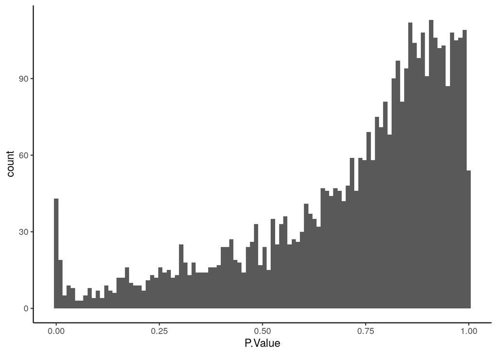

```r
ggplot(data_df, aes(x=P.Value)) + geom_histogram(bins=100)
```

This can easily be adjusted to other characteristics, such as expression or fold change:

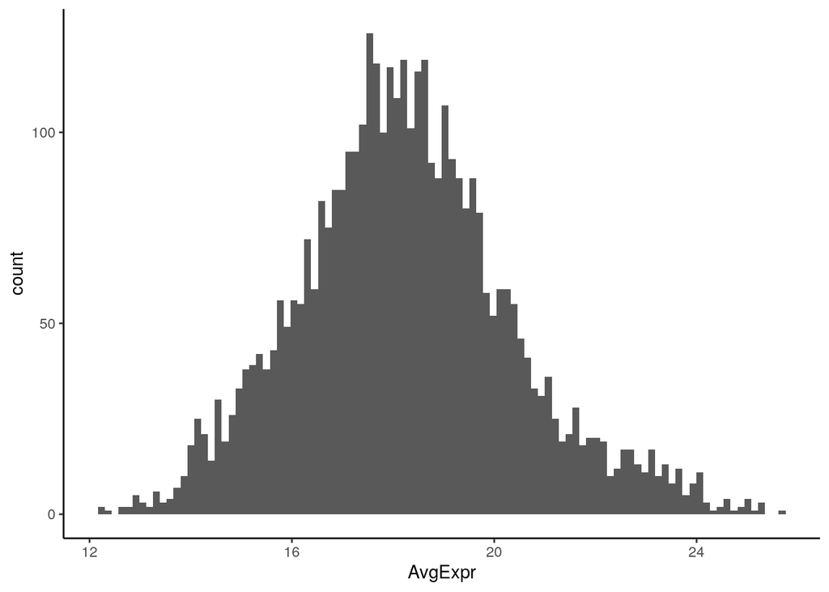

```r
ggplot(data_df, aes(x=AvgExpr)) + geom_histogram(bins=100)
```

**Exercise:** Further explore the `data_df` matrix using the histogram. Use `colnames` to inspect what columns there are in the matrix. Try making histograms for different columns, and try to adjust the number of bins in the histogram using the `bins` option.

## 3.2 Using multiple aesthetics - coloring the histogram

If you want to color those entries that pass your adjusted p-value threshold in a histogram, you can use the `fill` aesthetics.

Here, we want to highlight entries passing our assigned FDR threshold, which is specified in the column `IsFDRSig` that we created above.

The `#AAAAAA` is hexcode and a way to specify colors. The pairs of letters specify the amount of red, green and blue respectively.

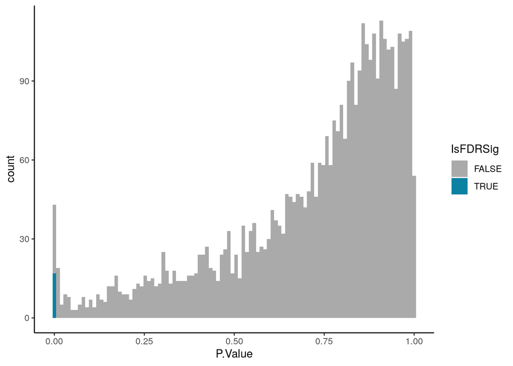

```r
gray_blue_colors <- c("#AAAAAA", "#0C81A2")

ggplot(data_df, aes(x=P.Value, fill=IsFDRSig)) + geom_histogram(bins=100) + scale_fill_manual(values=gray_blue_colors)
```

**Exercise:** Try changing the selected colors (you can find choices at the following link: https://www.w3schools.com/colors/colors_picker.asp).

**Exercise:** Try coloring based on other criteria than IsFDRSig (for instance IsSig)

**Challenge exercise:** Color based on if a feature is upregulated or not (i.e. if its fold-change is higher or lower than 0).

## 3.3 Volcano plot

The volcano plot gives a quick overview of the fold-changes and p-values within your dataset. The x-axis shows the log2-fold and the y-axis is rescaled p-values where the top ones are those with the lowest p-values.

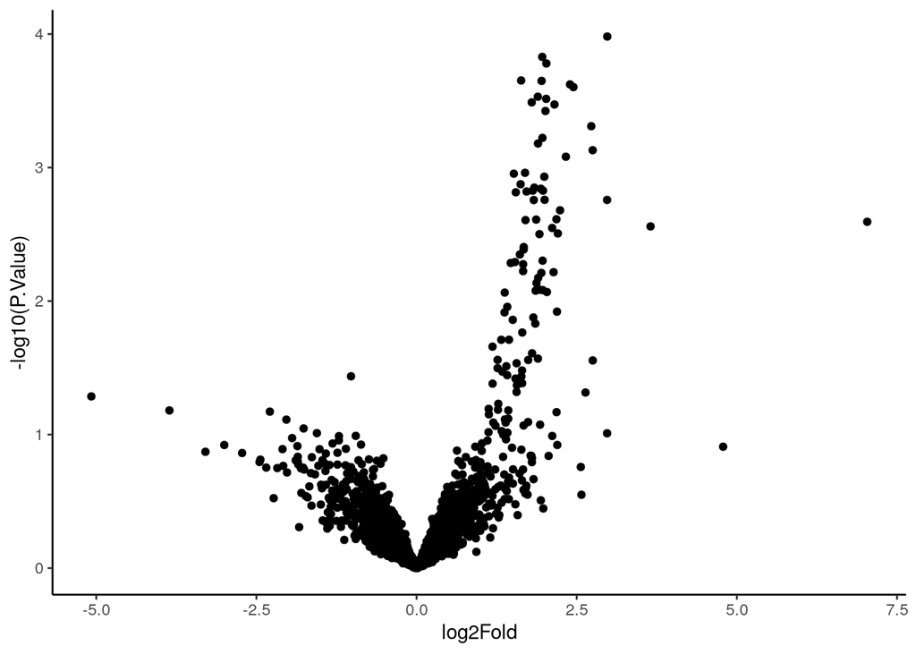

```r
ggplot(data_df, aes(x=log2Fold, y=-log10(P.Value))) + geom_point()
```

You can color the significant hits here too, similarly to in the p-value histogram.

```
## Warning: Removed 43 rows containing missing values (geom_point).
```

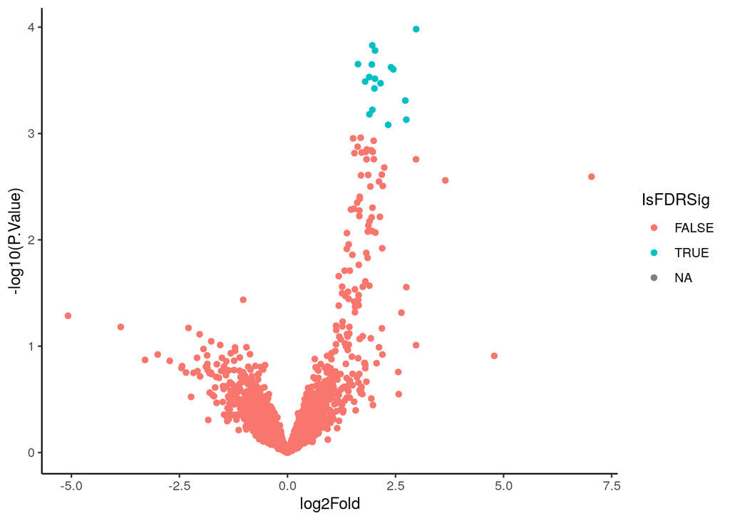

```r
ggplot(data_df, aes(x=log2Fold, y=-log10(P.Value), color=IsFDRSig)) + geom_point()
```

We can improve the visuals further by using the options:

- alpha - Make the dots partially transparent
- na.rm=TRUE - Omit the annoying warning message about NA values
- ggtitle - Add a title to the plot
- xlab / ylab - Custom axis-labels

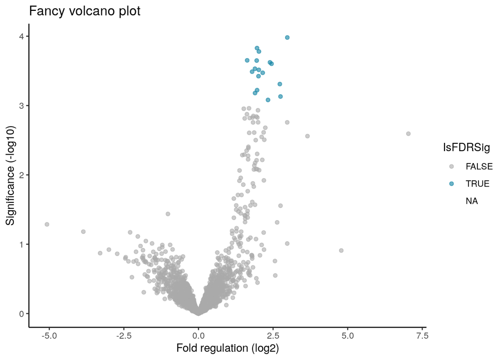

```r
ggplot(data_df, aes(x=log2Fold, y=-log10(P.Value), color=IsFDRSig)) +
    geom_point(alpha=0.6, na.rm=TRUE) +
    ggtitle("Fancy volcano plot") +
    xlab("Fold regulation (log2)") +
    ylab("Significance (-log10)") +
    scale_color_manual(values=gray_blue_colors)
```

**Exercise:** Try changing the x/y labels and the title

**Exercise:** Try adjusting the coloring aesthetics. Use a different column for coloring. You could also switch the coloring scheme.

**Thinking point:** When can we have a large fold change but still have a large p-value?

**Challenge exercise:** Add labels to the significant features. Instructions on how to achieve this can be found here: https://www.gettinggeneticsdone.com/2016/01/repel-overlapping-text-labels-in-ggplot2.html

## 3.4 MA plot

The MA plot is very similar to the vulcano plot, with the only difference what we are specifying as x-axis and y-axis.

The command `arrange(data_df, desc(P.Value))` is a Tidyverse command for sorting a data frame. Here, they are sorting with the features with the lowest p-values at the bottom to make sure they are drawn on top.

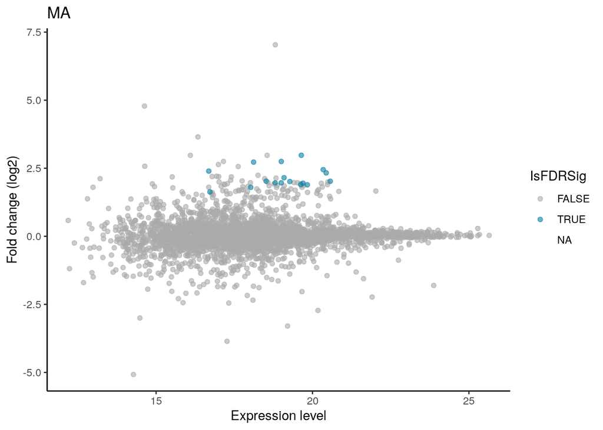

```r
ggplot(arrange(data_df, desc(P.Value)), aes(x=AvgExpr, y=log2Fold, color=IsFDRSig)) +
    geom_point(alpha=0.6, na.rm=TRUE) +
    ggtitle("MA") +
    xlab("Expression level") +
    ylab("Fold change (log2)") +
    scale_color_manual(values=gray_blue_colors)
```

**Exercise:** Take a look at the output from `arrange(data_df, desc(P.Value))`. Do you see what is going on if you compare it to the output from `data_df`?

# 4 Single feature illustrations

We often want to study intensity levels of selected features. We first need to prepare the data in the right format and then we can perform various visualizations.

`ggplot` expects the data to be in the so called ‘tidy’ format where one column contains the values, and the other columns contain information linked to that value. This is further discussed below in the “Preparing data in long format” section.

## 4.1 Preparing illustration for single features

First, we sort the data frame on the `P.Value` column and take a look at those with the highest and lowest p-value.

```r
head(arrange(data_df, P.Value))
```

```
##   Average.RT                  Cluster.ID Peptide.Sequence External.IDs
## 1   60.26076 1418128185272,1418128223206         VCFQYLNR       hum272
## 2   60.60463               1418128210770          IALDFQR       hum210
## 3   39.67873               1418128213014      ENAGEDPGLAR       hum240
## 4   48.64133               1418128214834     FLGEVHCGTNVR       hum269
## 5   62.81780               1418128211443        AGLQFPVGR       hum284
## 6   49.44278               1418128215034     HSDAVFTDNYTR       hum163
##   Charge Average.m.z      P.Value adj.P.Val log2Fold  AvgExpr   dil9_5
## 1      2    550.2725 0.0001043932 0.1214715 2.977166 19.64220       NA
## 2      2    431.7433 0.0001483525 0.1214715 1.961896 18.80728 20.18851
## 3      2    564.7685 0.0001660904 0.1214715 2.026260 18.51726 18.94022
## 4      2    694.8409 0.0002228151 0.1214715 1.632291 16.72149 17.47698
## 5      2    472.7698 0.0002243532 0.1214715 1.951682 19.69827 20.88876
## 6      2    713.3251 0.0002383996 0.1214715 2.395875 16.68474 17.36265
##     dil9_4   dil8_1   dil8_2   dil8_3   dil9_3   dil8_5   dil8_4   dil9_2
```

[output cut: 20 more lines]

```r
tail(arrange(data_df, P.Value))
```

```
##      Average.RT    Cluster.ID Peptide.Sequence  External.IDs Charge
## 4003   39.03130 1418128228099         VENSWGEK        Q99YL0      2
## 4004   42.78815 1418128228616          VIDTSIR        Q9A0J0      2
## 4005   47.62865 1418128210565          VINDFTK        P68900      2
## 4006   71.77410 1418128227443    VVDAFSTNFHLPK        Q99Z49      3
## 4007   39.75320 1418128216450         YADATSLK Q9A1H0,Q490W3      2
## 4008   63.88005 1418128223337       YLYTISPNIK        Q99ZR2      2
##      Average.m.z P.Value adj.P.Val log2Fold AvgExpr   dil9_5   dil9_4
## 4003    474.7267      NA        NA       NA      NA       NA       NA
## 4004    402.2355      NA        NA       NA      NA       NA       NA
## 4005    418.7291      NA        NA       NA      NA 24.06851 23.57863
## 4006    492.2607      NA        NA       NA      NA       NA       NA
## 4007    434.7244      NA        NA       NA      NA       NA       NA
## 4008    606.3358      NA        NA       NA      NA       NA       NA
##      dil8_1 dil8_2   dil8_3 dil9_3   dil8_5 dil8_4 dil9_2 dil9_1 dil8_6
```

[output cut: 20 more lines]

Next, we extract the top feature and put it in its own data frame. There are a few things going on here:

- `data_df$External.IDs` gives us the column only with the external IDs
- `data_df$External.IDs == "hum272"` will give us a long vector with TRUE/FALSE values (here only true for the “hum272” entry)
- `data_df[data_df$External.IDs == "hum272", ]` here we select all rows that are true in the previous vector (in this case - only one)
- `best_hit[, design_df$sample]` here `best_hit` is a single-row data frame. We subset it with the sample names from the design matrix so that we only have the values left.

```r
best_hit <- data_df[data_df$External.IDs == "hum272", ]
best_hit_vals <- best_hit[, design_df$sample]
print(best_hit)
```

```
##      Average.RT                  Cluster.ID Peptide.Sequence External.IDs
## 3495   60.26076 1418128185272,1418128223206         VCFQYLNR       hum272
##      Charge Average.m.z      P.Value adj.P.Val log2Fold AvgExpr dil9_5
## 3495      2    550.2725 0.0001043932 0.1214715 2.977166 19.6422     NA
##      dil9_4 dil8_1 dil8_2  dil8_3   dil9_3   dil8_5 dil8_4 dil9_2   dil9_1
## 3495     NA     NA     NA 18.4161 21.88865 16.26718     NA     NA 20.46198
##      dil8_6   dil9_6   dil8_7   dil9_7   dil8_8   dil9_8   dil8_9   dil9_9
## 3495     NA 20.66011 18.61546 20.27065 18.10826 21.73932 18.68445 20.95204
##      IsSig IsFDRSig
## 3495  TRUE     TRUE
```

```r
print(best_hit_vals)
```

```
##      dil9_5 dil9_4 dil8_1 dil8_2  dil8_3   dil9_3   dil8_5 dil8_4 dil9_2
## 3495     NA     NA     NA     NA 18.4161 21.88865 16.26718     NA     NA
##        dil9_1 dil8_6   dil9_6   dil8_7   dil9_7   dil8_8   dil9_8   dil8_9
## 3495 20.46198     NA 20.66011 18.61546 20.27065 18.10826 21.73932 18.68445
##        dil9_9
## 3495 20.95204
```

**Exercise:** Take a closer look at the code. Make sure you understand how the data is extracted from the dataframe.

The final step is to include these values in a new data frame. We use the `cbind` command to bind this value together with the design matrix. Now we have a data frame containing both the sample annotation information from the data frame and expression values for our feature of interest.

- `unlist` - `best_hit_vals` is a single-row data frame. To bind it we need it as a vector, which `unlist` does for us.
- `cbind` - “column bind”, let’s us bind one or many columns together (must have the same number of rows). The corresponding command for row-wise binding is `rbind`.

```r
best_hit_df <- cbind(value=unlist(best_hit_vals), design_df)
head(best_hit_df)
```

```
##           value sample group time dilution
## dil9_5       NA dil9_5    g9 late     high
## dil9_4       NA dil9_4    g9 late     high
## dil8_1       NA dil8_1    g8 late     high
## dil8_2       NA dil8_2    g8 late     high
## dil8_3 18.41610 dil8_3    g8 late     high
## dil9_3 21.88865 dil9_3    g9 late     high
```

## 4.2 Illustrating single features

Now we are ready to study this feature. At the same time, it is a good time to try out some different geometics, and try using multiple geometics at once.

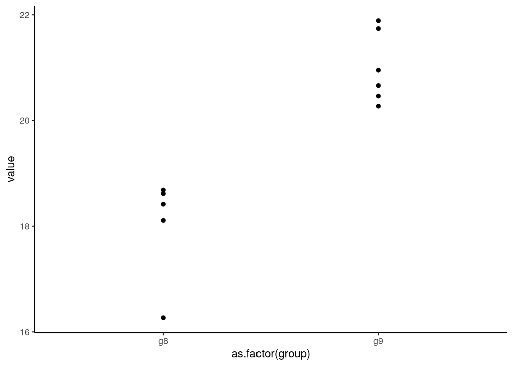

```r
ggplot(best_hit_df, aes(x=as.factor(group), y=value)) + geom_point()
```

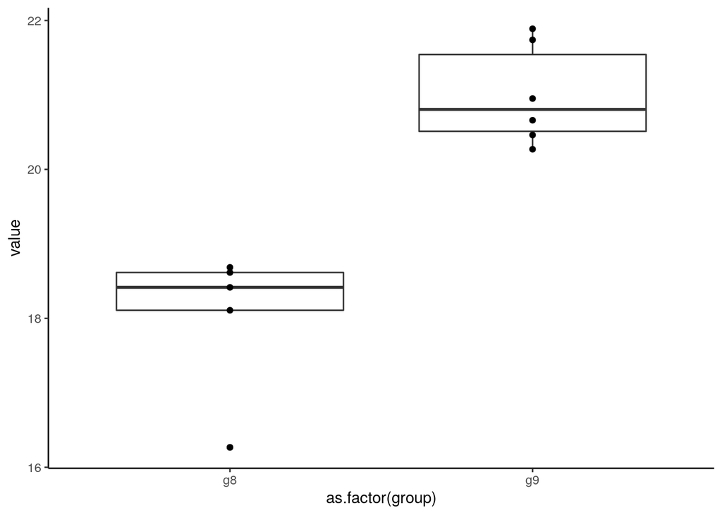

```r
ggplot(best_hit_df, aes(x=as.factor(group), y=value)) + geom_boxplot() + geom_point()
```

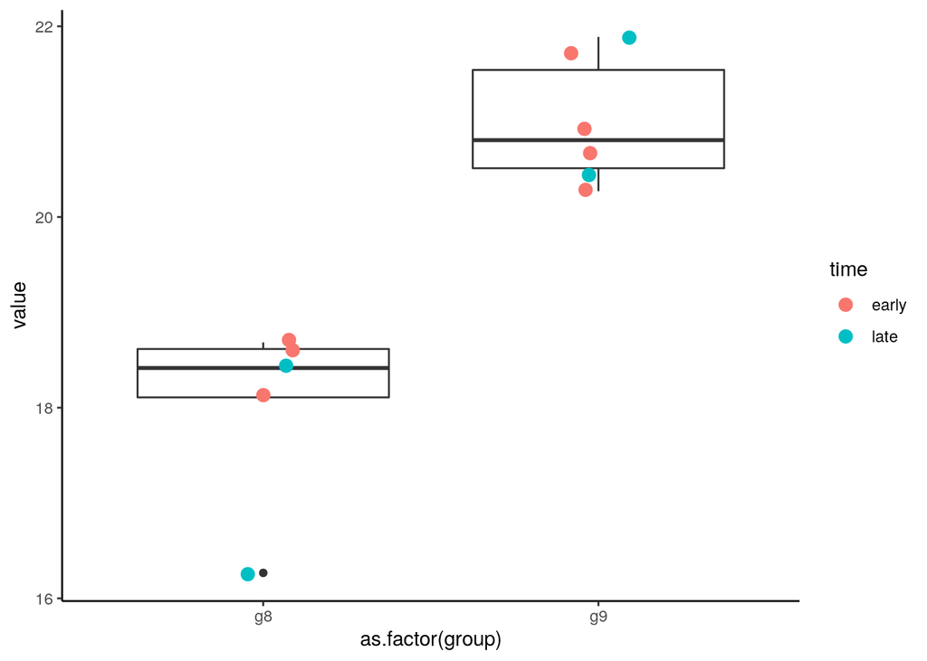

```r
ggplot(best_hit_df, aes(x=as.factor(group), y=value)) + geom_boxplot() + geom_point(aes(color=time), position=position_jitter(0.1), size=3)
```

**Exercise:** Do the same illustrations using the high p-value feature. Can you relate the figure to the p-values you have obtained?

**Exercise:** Try changing the coloring from “time” to “group” in the last plot. Does the results make sense?

**Exercise:** Update the xlabel, ylabel and title to be more illustrative

**Exercise:** Experiment with `position_jitter` setting. What happens if you change the value from `0.1` to `0.3`? To `0`? What happens if you change `position_jitter` to `position_jitter_dodge`? If you remove the entire argument?

**Exercise:** Try assigning `aes(color=time)` inside the `geom_boxplot` call (in the last plot).

# 5 Preparing data in long format

## 5.1 Wide vs. long formats

`ggplot` generally expects to get the data in the so called “long format”. This is different from the “wide format” we commonly used for expression matrices. Example of wide format, with one gene per row, and one sample per column:

```
gene   s1  s2  s3
gene_A  4   5   3
gene_B  3   2   3
```

The same matrix in long format:

```
gene   sample value
gene_A     s1     4
gene_A     s2     5
gene_A     s3     3
gene_B     s1     3
gene_B     s2     2
gene_B     s3     3
```

Here, all values are in one column, and we have a new column specifying to which sample they belong. Also notice that we have multiple rows for each gene (seen in the `gene` column). The long format is less pleasing for the human eye to look at, but makes it easier for `ggplot` as you only need to keep track of two columns to keep track of each sample and value.

This conversion can be made using the tidyverse-command `pivot_longer`. Here, you specify:

- The data frame to convert to long format
- What columns to transform (in our case - the sample columns)
- The names of the sample- and value-columns after conversion

Non-sample columns will follow along similarly to the `gene` column in the small example above.

```r
long_data <- pivot_longer(data_df, as.character(design_df$sample), names_to="sample", values_to="value")
head(long_data)
```

```
## # A tibble: 6 x 14
##   Average.RT Cluster.ID Peptide.Sequence External.IDs Charge Average.m.z
##        <dbl> <chr>      <chr>            <chr>         <int>       <dbl>
## 1       61.3 141812820… AAAAAAGDVFKDVQE… Q99Z57            3        555.
## 2       61.3 141812820… AAAAAAGDVFKDVQE… Q99Z57            3        555.
## 3       61.3 141812820… AAAAAAGDVFKDVQE… Q99Z57            3        555.
## 4       61.3 141812820… AAAAAAGDVFKDVQE… Q99Z57            3        555.
## 5       61.3 141812820… AAAAAAGDVFKDVQE… Q99Z57            3        555.
## 6       61.3 141812820… AAAAAAGDVFKDVQE… Q99Z57            3        555.
## # … with 8 more variables: P.Value <dbl>, adj.P.Val <dbl>, log2Fold <dbl>,
## #   AvgExpr <dbl>, IsSig <lgl>, IsFDRSig <lgl>, sample <chr>, value <dbl>
```

**Exercise:** Inspect the `long_data` table using the commands `dim`, `str` and `head`. Compare it to the wide format `data_df` data frame.

## 5.2 Visualizing sample density distributions

Having the data in long format we can now easily do sample-wide visualizations.

For instance, we can do density plots to see how the values in each sample is distributed.

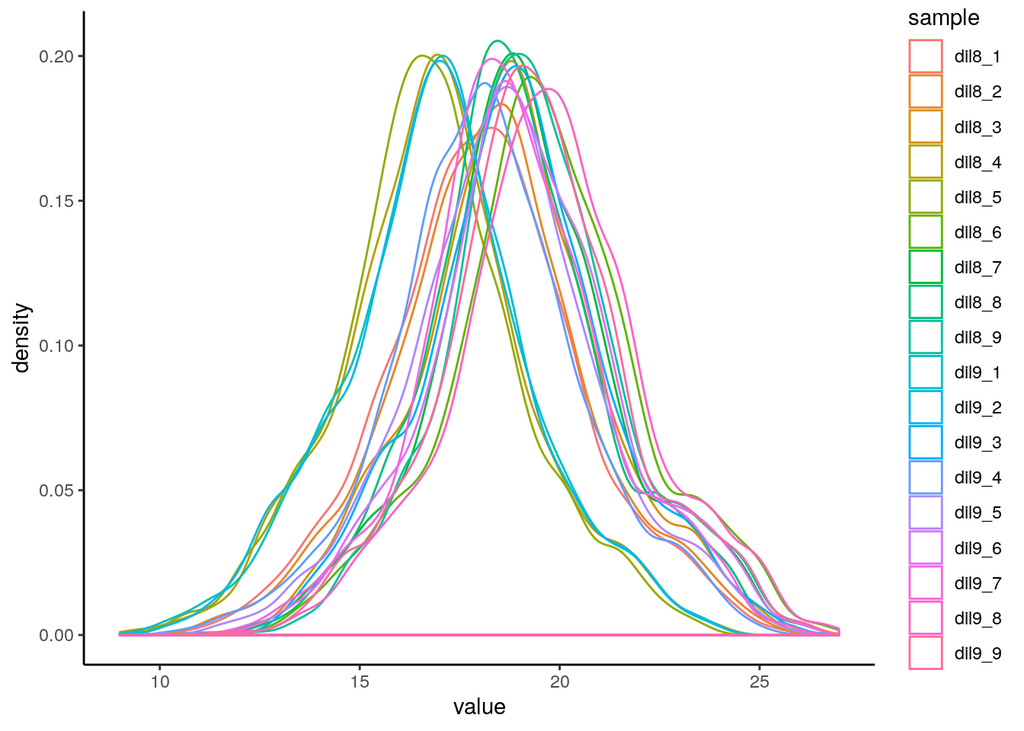

```r
ggplot(long_data, aes(x=value, color=sample)) + geom_density()
```

It looks like we have a four outliers here! (seen shifted to the left). These will likely cause problems in our downstream analysis if not handled with care.

## 5.3 Adding sample-annotation to the long dataframe

Often we want to color on different conditions to look for patterns in the data. Then we need to merge in out design matrix into this long data.

This can be achieved using a `left_join` from the `dplyr` package. Here, we specify the two matrices to merge, and which column we use for the merge.

```r
annot_long_data <- left_join(long_data, design_df, by="sample")
head(annot_long_data)
```

```
## # A tibble: 6 x 17
##   Average.RT Cluster.ID Peptide.Sequence External.IDs Charge Average.m.z
##        <dbl> <chr>      <chr>            <chr>         <int>       <dbl>
## 1       61.3 141812820… AAAAAAGDVFKDVQE… Q99Z57            3        555.
## 2       61.3 141812820… AAAAAAGDVFKDVQE… Q99Z57            3        555.
## 3       61.3 141812820… AAAAAAGDVFKDVQE… Q99Z57            3        555.
## 4       61.3 141812820… AAAAAAGDVFKDVQE… Q99Z57            3        555.
## 5       61.3 141812820… AAAAAAGDVFKDVQE… Q99Z57            3        555.
## 6       61.3 141812820… AAAAAAGDVFKDVQE… Q99Z57            3        555.
## # … with 11 more variables: P.Value <dbl>, adj.P.Val <dbl>,
## #   log2Fold <dbl>, AvgExpr <dbl>, IsSig <lgl>, IsFDRSig <lgl>,
## #   sample <chr>, value <dbl>, group <chr>, time <chr>, dilution <chr>
```

**Exercise::** Inspect the `annot_long_data` data frame and compare it to the `long_data` matrix. Do you see how the design matrix got added? How many columns were added? How many columns are there in the design dataframe?

## 5.4 Density plots

Now we can use different characteristics found in the design matrix to study the sample densities. Note that we need to use the `group` aesthetics to separate the samples when using other colorings.

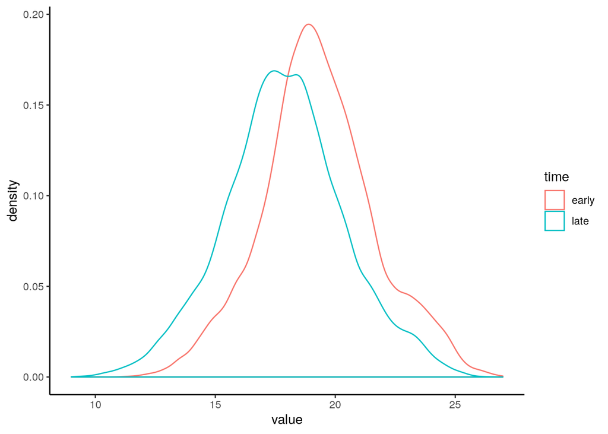

```r
ggplot(annot_long_data, aes(x=value, color=time)) + geom_density()
```

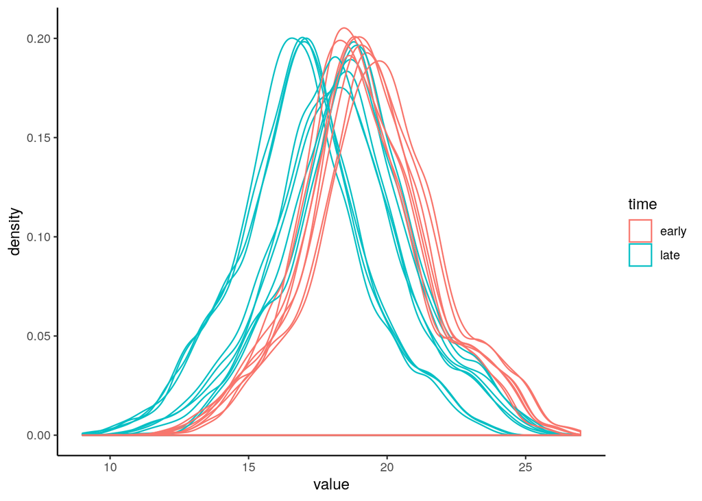

```r
ggplot(annot_long_data, aes(x=value, color=time, group=sample)) + geom_density()
```

**Exercise:** There are a lot of technical influence going on in this dataset. Can you spot the two batch effects by visually inspecting the figure?

**Exercise:** Try coloring the figure on other sample characteristics found in the data frame. Can you spot which matches the pattern? Do you see why these samples are shifted this way?

## 5.5 Boxplot or violins

Now we can easily do boxplots and other illustrations of our samples.

Here, we use the `theme` option to adjust the x-axis labels (`axis.text.x`) and to rotate them 90 degrees. We also adjust them to be nicely aligned with the ticks. The `theme` option is a powerful aspect of ggplot which lets you target in principle any aspects for the figures and change fonts, colorings, text orientations and much more.

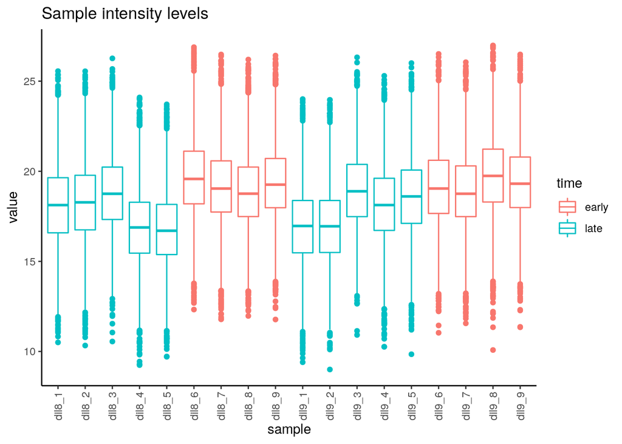

```r
ggplot(annot_long_data, aes(x=sample, y=value, color=time)) +
    geom_boxplot() +
    theme(axis.text.x = element_text(angle=90, vjust=0.5)) +
    ggtitle("Sample intensity levels")
```

**Exercise:** See if you can make a violin plot for the densities (tips: the geom for the violin plot is `geom_violin`).

**Exercise:** Try adjusting the `vjust` value. Do you see what is happening?

**Challenge exercise:** See if you can rotate the y-axis labels.

# 6 Special topics

## 6.1 Making a multi-pane plot

You often want to combine multiple plots

```r
library(ggpubr)
```

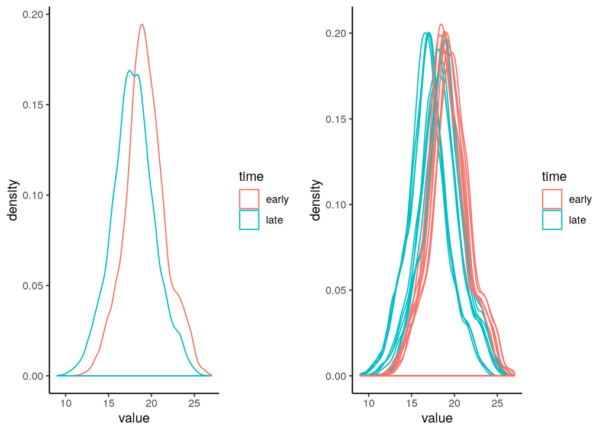

```r
dens1 <- ggplot(annot_long_data, aes(x=value, color=time)) + geom_density()
dens2 <- ggplot(annot_long_data, aes(x=value, color=time, group=sample)) + geom_density()
ggarrange(dens1, dens2)
```

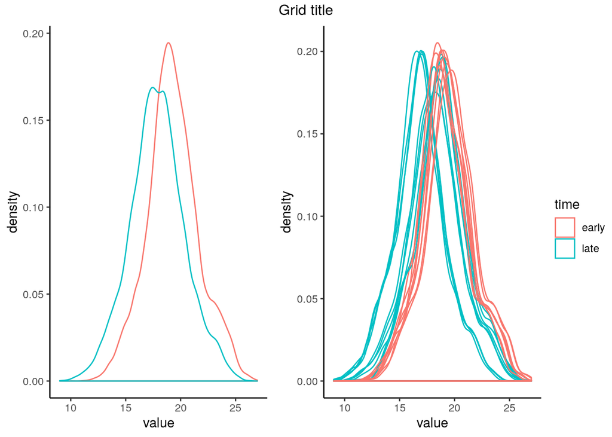

```r
grid_plt <- ggarrange(dens1, dens2, common.legend = TRUE, legend = "right")
annotated_plt <- annotate_figure(grid_plt, top="Grid title")
annotated_plt
```

## 6.2 Saving plots to file

```r
ggsave(annotated_plt, filename = "output_path.png")
```

You can specify the measures, and the resolution.

```r
ggsave(annotated_plt, filename = "output_path_highres.png", width=10, height=10, dpi = 300)
```

# 7 Special cases

## 7.1 Heatmaps

Source: https://learnr.wordpress.com/2010/01/26/ggplot2-quick-heatmap-plotting/ Source for base R: https://www.r-graph-gallery.com/heatmap

Heatmaps can be done in ggplot using `geom_tile()`, but in this particular case I would recommend using the base R version due to its clustering of the entries.

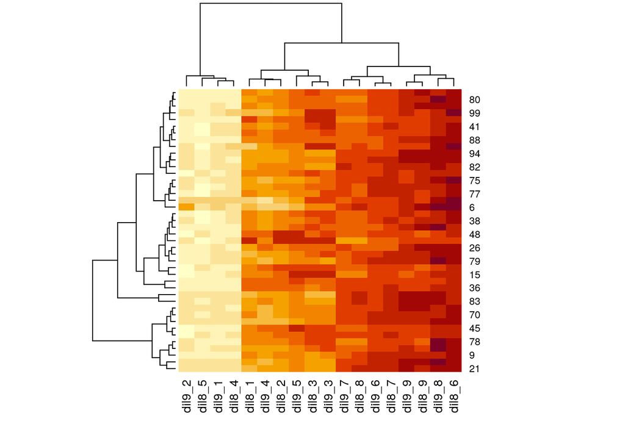

```r
library(tidyverse)

heatmap(data_df %>% head(100) %>% dplyr::select(design_df$sample) %>% as.matrix() %>% na.omit())
```

```r
colnames(data_df) <- make.names(colnames(data_df))
out <- data_df %>%
    arrange(P.Value) %>%
    head(10) %>%
    pivot_longer(as.character(design_df$sample), names_to="sample", values_to="value") %>%
    filter(!is.na(value))
head(out)
```

```
## # A tibble: 6 x 14
##   Average.RT Cluster.ID Peptide.Sequence External.IDs Charge Average.m.z
##        <dbl> <chr>      <chr>            <chr>         <int>       <dbl>
## 1       60.3 141812818… VCFQYLNR         hum272            2        550.
## 2       60.3 141812818… VCFQYLNR         hum272            2        550.
## 3       60.3 141812818… VCFQYLNR         hum272            2        550.
## 4       60.3 141812818… VCFQYLNR         hum272            2        550.
## 5       60.3 141812818… VCFQYLNR         hum272            2        550.
## 6       60.3 141812818… VCFQYLNR         hum272            2        550.
## # … with 8 more variables: P.Value <dbl>, adj.P.Val <dbl>, log2Fold <dbl>,
## #   AvgExpr <dbl>, IsSig <lgl>, IsFDRSig <lgl>, sample <chr>, value <dbl>
```

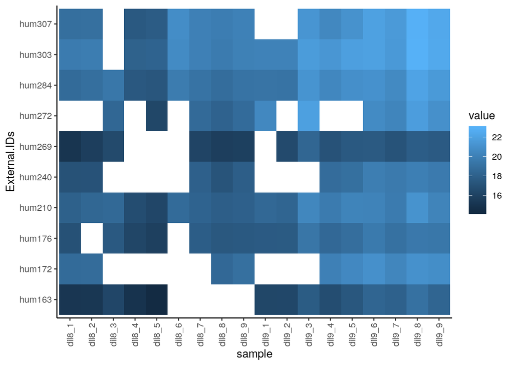

```r
ggplot(out, aes(sample, External.IDs)) +
    geom_tile(aes(fill=value)) +
    theme(axis.text.x = element_text(angle=90, vjust=0.5))
```

## 7.2 Principal component analysis

There are many ways to do principal component analysis visualizations in R. The one I find easiest to use is the `PCAtools` package.

Here is a nice vignette for more extensive examples: https://bioconductor.org/packages/release/bioc/vignettes/PCAtools/inst/doc/PCAtools.html

```r
library(PCAtools)
```

```r
# Biplots for different components and colorings
# Pairplot

data_only <- data_df[, design_df$sample]

data_only_no_missing <- data_only[complete.cases(data_only), ]

p <- pca(data_only_no_missing, removeVar=0.1, scale=TRUE, metadata=as.matrix(design_df))
```

```
## -- removing the lower 10% of variables based on variance
```

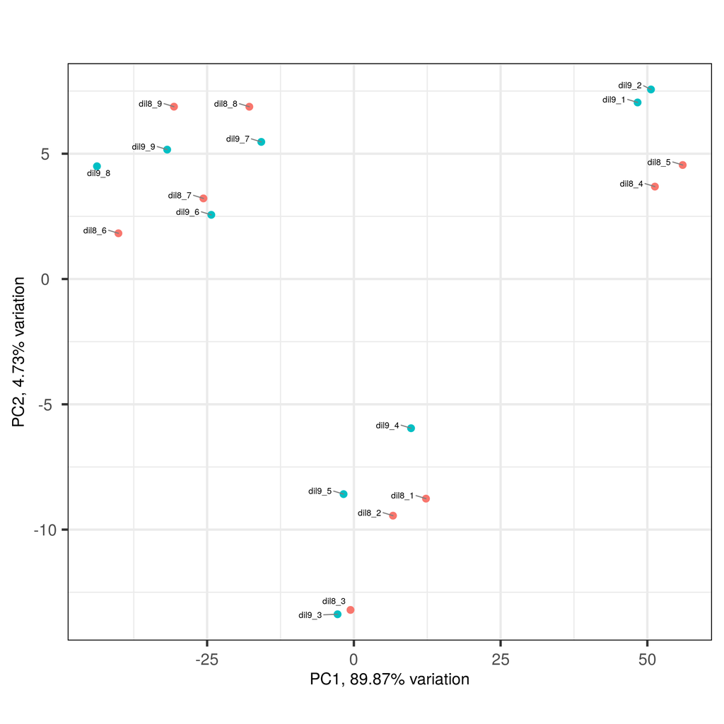

```r
biplot(p, colby = "group")
```

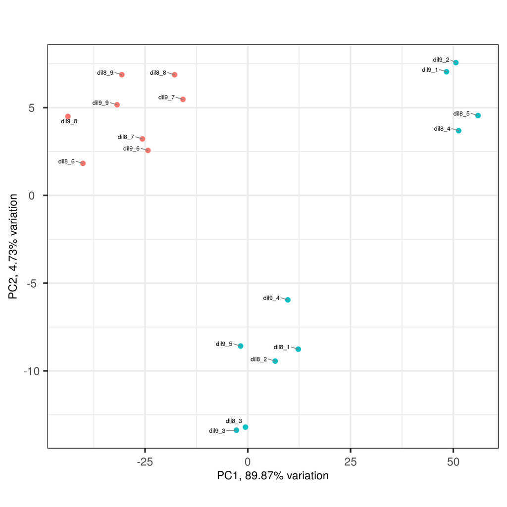

```r
biplot(p, colby = "time")
```

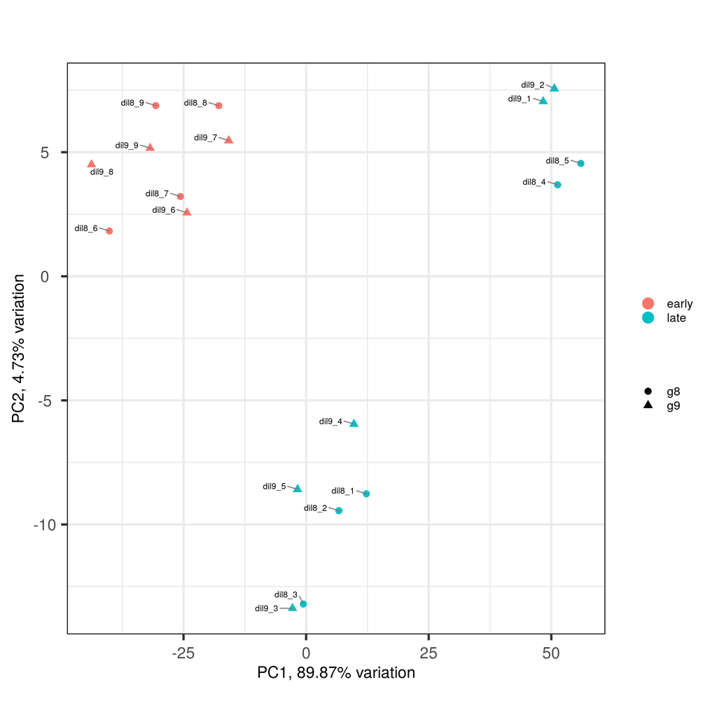

```r
biplot(p, colby = "time", shape="group", legendPosition = "right")
```

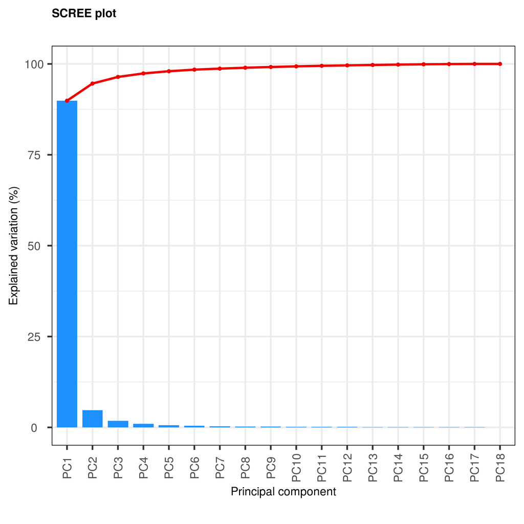

```r
screeplot(p)
```

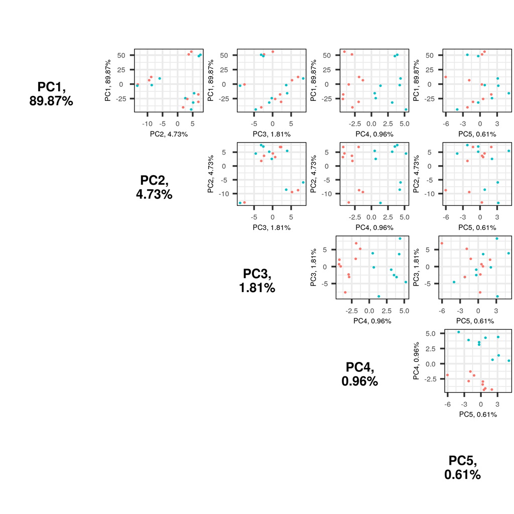

```r
pairsplot(p, colby = "group")
```

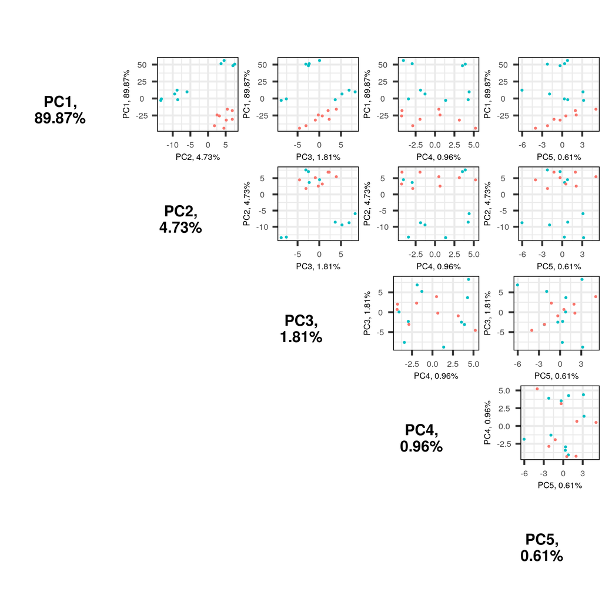

```r
pairsplot(p, colby = "time")
```